# **Group Project - The relationship between Metacritic score and video games over time and over console.**

### By Justin Levine and Joshua Zarb

## Introduction

Over the past couple of years, while our group members were playing video games, we wondered that despite video game graphics and sounds improving, was the overall quality of video games also improving?

Video game consoles are often split into "generations", based on their release date and their main competitors. The 7th generation, beginning around 2005, brought several trends in video gaming: more focus on online interaction, a shift towards Western developers, and more mainstream recognition of gaming.

On the other hand, many are enthusiasts of older consoles such as the PlayStation. We wanted to examine if there was any evidence to support either preference. To explore this we used Metacritic (a website that aggregates reviews for video games) to determine how the quality of video games has changed over the years, comparing pre- and post-7th generation games.

## Data scraping

We started off our project by importing the necessary libraries to start our data analysis.

```python
import sqlite3
import pandas as pd
import matplotlib.pyplot as plt
import numpy as np
import seaborn as sns
import datetime
from sklearn import model_selection
import sklearn.linear_model
import statsmodels.api as sm
import warnings
warnings.filterwarnings('ignore')
warnings.simplefilter('ignore')

from google.colab import drive
drive.mount('/content/drive')
```

To begin the analysis we first obtained data on various video games' Metacritic scores from this website: https://www.kaggle.com/datasets/deepcontractor/top-video-games-19952021-metacritic. This dataset is an already scraped version of Metacritic's list, available on their website at https://www.metacritic.com/browse/games/score/metascore/all/all.

```python
games_file = "/content/drive/MyDrive/all_games.csv"
games = pd.read_csv(games_file)
display(games.head())
```

|  | name | platform | release_date | summary | meta_score | user_review |
| --- | --- | --- | --- | --- | --- | --- |
| 0 | The Legend of Zelda: Ocarina of Time | Nintendo 64 | November 23, 1998 | As a young boy, Link is tricked by Ganondorf, ... | 99 | 9.1 |
| 1 | Tony Hawk's Pro Skater 2 | PlayStation | September 20, 2000 | As most major publishers' development efforts ... | 98 | 7.4 |
| 2 | Grand Theft Auto IV | PlayStation 3 | April 29, 2008 | [Metacritic's 2008 PS3 Game of the Year; Also ... | 98 | 7.7 |
| 3 | SoulCalibur | Dreamcast | September 8, 1999 | This is a tale of souls and swords, transcendi... | 98 | 8.4 |
| 4 | Grand Theft Auto IV | Xbox 360 | April 29, 2008 | [Metacritic's 2008 Xbox 360 Game of the Year; ... | 98 | 7.9 |

From this data we are able to determine, for each video game: the name of the video game, the platform on which it was released on, the year that it was released, a description of the game itself, the metascore, and finally the user reviews. The metascore and user reviews are both numerical reviews of a game's quality, but the metascore is an average of a game's review scores from a select set of critics, whereas the user score is an average of the scores from every Metacritic user who gives a rating.

## Tidying data

Next, we can perform some operations on our dataset to tidy it up and make it easier to work with.

```python
# Some games have a user review of "tbd". Let's change that to NaN.
# Critic reviews are integers from 0-100, while user reviews are floats scaled from 0-10. Let's scale user reviews so they're out of 0-100.
games["user_review"] = games["user_review"].apply(lambda x: np.nan if x == "tbd" else (int)(float(x) * 10))

# We'll also drop games that don't currently have a user review.
games.dropna(subset = ["user_review"], inplace = True)

# Every entry in the platform column has a whitespace character at the start. We can strip this whitespace.
games["platform"] = games["platform"].apply(lambda x: x.strip())

# Each entry in the release_date column is of type string, instead of datetime. Let's change it to type datetime, so it's easier to work with.
games["release_date"] = games["release_date"].apply(lambda x: datetime.datetime.strptime(x, "%B %d, %Y"))

games.reset_index(drop = True, inplace = True)
display(games)
```

|  | name | platform | release_date | summary | meta_score | user_review |
| --- | --- | --- | --- | --- | --- | --- |
| 0 | The Legend of Zelda: Ocarina of Time | Nintendo 64 | 1998-11-23 | As a young boy, Link is tricked by Ganondorf, ... | 99 | 91.0 |
| 1 | Tony Hawk's Pro Skater 2 | PlayStation | 2000-09-20 | As most major publishers' development efforts ... | 98 | 74.0 |
| 2 | Grand Theft Auto IV | PlayStation 3 | 2008-04-29 | [Metacritic's 2008 PS3 Game of the Year; Also ... | 98 | 77.0 |
| 3 | SoulCalibur | Dreamcast | 1999-09-08 | This is a tale of souls and swords, transcendi... | 98 | 84.0 |
| 4 | Grand Theft Auto IV | Xbox 360 | 2008-04-29 | [Metacritic's 2008 Xbox 360 Game of the Year; ... | 98 | 79.0 |
| ... | ... | ... | ... | ... | ... | ... |
| 17430 | Fast & Furious: Showdown | Xbox 360 | 2013-05-21 | Fast & Furious: Showdown takes some of the fra... | 22 | 13.0 |
| 17431 | Drake of the 99 Dragons | Xbox | 2003-11-03 | Drake is out for revenge in a supernatural Hon... | 22 | 17.0 |
| 17432 | Afro Samurai 2: Revenge of Kuma Volume One | PlayStation 4 | 2015-09-22 | Head out on a journey of redemption, driven by... | 21 | 29.0 |
| 17433 | Infestation: Survivor Stories (The War Z) | PC | 2012-10-15 | (Formerly known as "The War Z") It has been 5 ... | 20 | 17.0 |
| 17434 | Leisure Suit Larry: Box Office Bust | PC | 2009-03-31 | The Leisure Suit Larry: Box Office Bust video ... | 20 | 20.0 |

17435 rows × 6 columns

We now have a dataset of over 17,000 games across various consoles.

For the purposes of this project, we will divide each game into one of two categories: "old" or "new", depending on whether the game was released for a pre- or post-7th generation console. Which generation each console fits into will be described below.

```python
print(games["platform"].drop_duplicates())
```

```
0            Nintendo 64
1            PlayStation
2          PlayStation 3
3              Dreamcast
4               Xbox 360
5                    Wii
7               Xbox One
10                    PC
13                Switch
14         PlayStation 2
16         PlayStation 4
18              GameCube
21                  Xbox
26                 Wii U
53      Game Boy Advance
79                   3DS
120        Xbox Series X
122                   DS
141     PlayStation Vita
157        PlayStation 5
328                  PSP
3879              Stadia
Name: platform, dtype: object
```

This is a list of all consoles that have at least one game in our dataset. We can then divide this list into old and new consoles and split the dataset into two halves, one for each category.

As mentioned earlier, video game consoles are typically split into "generations". We can determine the generation each console belongs to and assign them to a category. Metacritic's earliest data is on 5th generation consoles, so 5th and 6th generation consoles will be in the "old" category.

- 5th generation: Nintendo 64, PlayStation
- 6th generation: Dreamcast, PlayStation 2, GameCube, Xbox, Game Boy Advance

Likewise, the 9th generation is the current generation, so consoles in the 7th to 9th generations will be in the "new" category.

- 7th generation: PlayStation 3, Xbox 360, Wii, DS, PSP
- 8th generation: Xbox One, Wii U, PlayStation 4, 3DS, PlayStation Vita
- 9th generation: Switch, Xbox Series X, PlayStation 5, Stadia

The one anomaly in this list is the PC. Because "PC" is often a catch-all term that refers to any kind of Windows computer, games have consistently released on PC, even going back to the 1990s. Since the PC does not fit into any one console generation, and since it is not mainly considered a video game console, the PC will not be placed in either category.

```python
games = games[games["platform"] != "PC"]

old_games_list = ["Nintendo 64", "PlayStation", "Dreamcast", "PlayStation 2", "GameCube", "Xbox", "Game Boy Advance"]
new_games_list = ["PlayStation 3", "Xbox 360", "Wii", "Xbox One", "Switch", "PlayStation 4", "Wii U", "3DS", "Xbox Series X", "DS", "PlayStation Vita", "PlayStation 5", "PSP", "Stadia"]

old_games = pd.DataFrame()
new_games = pd.DataFrame()
games["new_console"] = games["platform"].apply(lambda x: 1 if x in new_games_list else 0)

old_games = games[games["new_console"] == 0].reset_index(drop = True)
new_games = games[games["new_console"] == 1].reset_index(drop = True)
old_games.drop(["new_console"], axis = 1, inplace = True)
new_games.drop(["new_console"], axis = 1, inplace = True)

display(old_games)
display(new_games)
```

|  | name | platform | release_date | summary | meta_score | user_review |
| --- | --- | --- | --- | --- | --- | --- |
| 0 | The Legend of Zelda: Ocarina of Time | Nintendo 64 | 1998-11-23 | As a young boy, Link is tricked by Ganondorf, ... | 99 | 91.0 |
| 1 | Tony Hawk's Pro Skater 2 | PlayStation | 2000-09-20 | As most major publishers' development efforts ... | 98 | 74.0 |
| 2 | SoulCalibur | Dreamcast | 1999-09-08 | This is a tale of souls and swords, transcendi... | 98 | 84.0 |
| 3 | Tony Hawk's Pro Skater 2 | Dreamcast | 2000-11-06 | Hawk's back - with new technology, new pros an... | 97 | 62.0 |
| 4 | Tony Hawk's Pro Skater 3 | PlayStation 2 | 2001-10-28 | Challenge up to four friends in online competi... | 97 | 75.0 |
| ... | ... | ... | ... | ... | ... | ... |
| 3110 | Gravity Games Bike: Street Vert Dirt | PlayStation 2 | 2002-06-27 | Gravity Games Bike: Street. Vert. Dirt. delive... | 24 | 34.0 |
| 3111 | Legends of Wrestling II | Game Boy Advance | 2002-11-25 | Legends of Wrestling II takes you through the ... | 24 | 36.0 |
| 3112 | Pulse Racer | Xbox | 2003-01-02 | Pulse Racer takes you to a future where racers... | 24 | 22.0 |
| 3113 | Charlie's Angels | GameCube | 2003-07-09 | Join Natalie, Dylan, and Alex for an intense a... | 23 | 43.0 |
| 3114 | Drake of the 99 Dragons | Xbox | 2003-11-03 | Drake is out for revenge in a supernatural Hon... | 22 | 17.0 |

3115 rows × 6 columns

|  | name | platform | release_date | summary | meta_score | user_review |
| --- | --- | --- | --- | --- | --- | --- |
| 0 | Grand Theft Auto IV | PlayStation 3 | 2008-04-29 | [Metacritic's 2008 PS3 Game of the Year; Also ... | 98 | 77.0 |
| 1 | Grand Theft Auto IV | Xbox 360 | 2008-04-29 | [Metacritic's 2008 Xbox 360 Game of the Year; ... | 98 | 79.0 |
| 2 | Super Mario Galaxy | Wii | 2007-11-12 | [Metacritic's 2007 Wii Game of the Year] The u... | 97 | 91.0 |
| 3 | Super Mario Galaxy 2 | Wii | 2010-05-23 | Super Mario Galaxy 2, the sequel to the galaxy... | 97 | 91.0 |
| 4 | Red Dead Redemption 2 | Xbox One | 2018-10-26 | Developed by the creators of Grand Theft Auto ... | 97 | 80.0 |
| ... | ... | ... | ... | ... | ... | ... |
| 9655 | Fighter Within | Xbox One | 2013-11-19 | Unleash your inner fighter to beat your friend... | 23 | 28.0 |
| 9656 | Homie Rollerz | DS | 2008-03-05 | Homie Rollerz is a fast-paced, mayhem-laden ka... | 23 | 30.0 |
| 9657 | Rambo: The Video Game | PlayStation 3 | 2014-04-29 | RAMBO The Vidoegame puts players in Rambo’s co... | 23 | 18.0 |
| 9658 | Fast & Furious: Showdown | Xbox 360 | 2013-05-21 | Fast & Furious: Showdown takes some of the fra... | 22 | 13.0 |
| 9659 | Afro Samurai 2: Revenge of Kuma Volume One | PlayStation 4 | 2015-09-22 | Head out on a journey of redemption, driven by... | 21 | 29.0 |

9660 rows × 6 columns

We now have each game marked as being for an "old"(pre-7th generation) or "new"(post-7th generation) console. Additionally, we have two new dataframes corresponding to games for each category.

Now that we have our datasets divided properly, we should also check the release dates of each game to make sure everything is correct.

```python
display(old_games.sort_values(by = "release_date"))
display(new_games.sort_values(by = "release_date"))
```

|  | name | platform | release_date | summary | meta_score | user_review |
| --- | --- | --- | --- | --- | --- | --- |
| 132 | Resident Evil | PlayStation | 1996-03-30 | Raccoon City has been completely overrun by mu... | 91 | 91.0 |
| 207 | Tekken 2 | PlayStation | 1996-08-25 | More than a sequel. The undisputed #1 fighting... | 89 | 83.0 |
| 47 | Super Mario 64 | Nintendo 64 | 1996-09-26 | Mario is super in a whole new way! Combining t... | 94 | 91.0 |
| 832 | Pilotwings 64 | Nintendo 64 | 1996-09-29 | Forget about those other flying games. This is... | 80 | 81.0 |
| 70 | Wipeout XL | PlayStation | 1996-09-30 | The original scorched the game world and becam... | 93 | 86.0 |
| ... | ... | ... | ... | ... | ... | ... |
| 2757 | Werewolf: The Apocalypse - Earthblood | PlayStation 2 | 2021-02-04 | A unique experience full of savage combat and ... | 54 | 38.0 |
| 2797 | Taxi Chaos | PlayStation 2 | 2021-02-23 | Taxi Chaos is a casual arcade racing game wher... | 52 | 59.0 |
| 2744 | Harvest Moon: One World | GameCube | 2021-03-02 | Take a trip around the world in the latest ent... | 54 | 44.0 |
| 2911 | Demon Skin | GameCube | 2021-04-13 | Brutal Hack&Slash game with a challenging comb... | 48 | 75.0 |
| 2799 | Akiba's Trip: Hellbound & Debriefed | Game Boy Advance | 2021-07-20 | AKIBA’S TRIP: Hellbound & Debriefed is the pre... | 52 | 54.0 |

3115 rows × 6 columns

|  | name | platform | release_date | summary | meta_score | user_review |
| --- | --- | --- | --- | --- | --- | --- |
| 8569 | Postal | Wii | 1997-09-30 | We'd like to express our sincere thanks and gr... | 56 | 65.0 |
| 9374 | Jeremy McGrath Supercross 2000 | PlayStation 4 | 1999-09-29 | Race as or against 11-time Supercross Champ Je... | 43 | 80.0 |
| 9414 | Rally Challenge 2000 | Xbox 360 | 2000-06-30 | RALLY CHALLENGE 2000 takes you on a scorching ... | 41 | 60.0 |
| 8724 | Fighter Destiny 2 | PSP | 2000-07-14 | Enter the arena and do battle with the toughes... | 54 | 65.0 |
| 8923 | Sydney 2000 | Switch | 2000-08-25 | Let the games begin, Mate! Get ready to compet... | 51 | 49.0 |
| ... | ... | ... | ... | ... | ... | ... |
| 4392 | Far Cry 6 | PlayStation 5 | 2021-10-07 | Far Cry 6 reveals a Caribbean island simmering... | 74 | 48.0 |
| 26 | Tetris Effect: Connected | Switch | 2021-10-08 | Tetris Effect: Connected is the original Tetri... | 95 | 85.0 |
| 239 | Metroid Dread | Switch | 2021-10-08 | Join intergalactic bounty hunter Samus Aran in... | 89 | 88.0 |
| 440 | Disco Elysium: The Final Cut | Switch | 2021-10-12 | Disco Elysium - The Final Cut is the definitiv... | 87 | 87.0 |
| 5248 | Demon Slayer: Kimetsu no Yaiba - The Hinokami ... | PlayStation 5 | 2021-10-13 | Players can relive the story of Tanjiro Kamado... | 72 | 75.0 |

9660 rows × 6 columns

Oddly, the dataset of games for "old" consoles has points with release dates as late as 2021. This makes no sense, as the longest lasting console in this set (PlayStation 2) was discontinued in 2013. Likewise, the dataset of games for "new" consoles has games with release dates as early as 1997, even though the earliest new console (DS) was released in 2004. Most of these games also do not show up on the search engine on Metacritic's website, which further suggests that they are some kind of anomaly.

```python
display(old_games[old_games["release_date"] >= pd.to_datetime(datetime.date(2014, 1, 1))])
display(new_games[new_games["release_date"] < pd.to_datetime(datetime.date(2004, 1, 1))])
```

|  | name | platform | release_date | summary | meta_score | user_review |
| --- | --- | --- | --- | --- | --- | --- |
| 2653 | Surgeon Simulator: Anniversary Edition | Dreamcast | 2014-08-12 | Surgeon Simulator 2013 is a darkly humorous ov... | 56 | 51.0 |
| 2660 | Pokemon Shuffle | Game Boy Advance | 2015-02-18 | In Pokémon Shuffle, your goal is to clear a se... | 56 | 61.0 |
| 2662 | Perception | Game Boy Advance | 2017-06-06 | A first person narrative horror adventure that... | 56 | 61.0 |
| 2663 | Deadly Premonition 2: A Blessing in Disguise | Xbox | 2020-07-10 | In the year 2005, FBI agent York visits Le Car... | 56 | 54.0 |
| 2667 | Supreme League of Patriots | PlayStation 2 | 2015-01-29 | Don your cape and mask and join the Supreme Le... | 56 | 46.0 |
| ... | ... | ... | ... | ... | ... | ... |
| 3032 | Tennis World Tour | PlayStation 2 | 2018-05-22 | The new standard developed by veterans of tenn... | 42 | 18.0 |
| 3033 | Rugby 18 | PlayStation | 2017-10-24 | Experience the full intensity of the biggest m... | 41 | 38.0 |
| 3039 | Dollhouse | PlayStation 2 | 2019-05-24 | This haunting horror game draws you into the m... | 41 | 44.0 |
| 3046 | Tamarin | PlayStation | 2020-09-10 | SAVE YOUR FAMILY FROM THE INSECT INVASION Expl... | 40 | 68.0 |
| 3051 | The Deer God | PlayStation 2 | 2017-12-21 | The Deer God is a breathtaking 3D pixel art ad... | 39 | 27.0 |

95 rows × 6 columns

|  | name | platform | release_date | summary | meta_score | user_review |
| --- | --- | --- | --- | --- | --- | --- |
| 8521 | Reign of Fire | Xbox 360 | 2002-10-22 | Fight for mankind as one of the many different... | 56 | 75.0 |
| 8536 | Spyro: Enter the Dragonfly | 3DS | 2002-11-03 | Gnasty Gnorc and Ripto are back with a plan to... | 56 | 44.0 |
| 8543 | Harry Potter and the Sorcerer's Stone | DS | 2003-12-09 | The next generation versions of Sorcerer's Sto... | 56 | 66.0 |
| 8544 | Contract J.A.C.K. | Wii | 2003-11-11 | Trained to survive. Paid to kill. Explore the ... | 56 | 60.0 |
| 8568 | Cool Boarders 2001 | Wii | 2000-10-31 | Rip it up with 10 World Class professional sno... | 56 | 33.0 |
| ... | ... | ... | ... | ... | ... | ... |
| 9446 | Freedom: First Resistance | Switch | 2000-12-14 | Earth has been invaded by aliens that have for... | 40 | 32.0 |
| 9464 | Ultimate Beach Soccer | Xbox 360 | 2003-11-10 | With flashy moves, laser shows, and DJs, Ultim... | 39 | 68.0 |
| 9467 | Air Raid: This Is Not a Drill! | Wii | 2003-06-18 | Air Raid immerses you in a mind blowing, reali... | 39 | 66.0 |
| 9485 | Universal Studios Theme Parks Adventure | PlayStation 3 | 2001-12-18 | Lights... Camera... PLAY! You're not just a vi... | 39 | 32.0 |
| 9490 | Star Wars: Flight of the Falcon | Switch | 2003-11-18 | In Star Wars: Flight of the Falcon, you get th... | 39 | 59.0 |

127 rows × 6 columns

These rows do not make up a large part of the dataset. For the games for old consoles, they make up 95 out of 3,115 rows, and for the games for new consoles, they make up 127 out of 9,660 rows. To keep the data focused on relevant points, we will remove these rows from the split datasets.

```python
old_games = old_games[old_games["release_date"] < pd.to_datetime(datetime.date(2014, 1, 1))].reset_index(drop = True)
new_games = new_games[new_games["release_date"] >= pd.to_datetime(datetime.date(2004, 1, 1))].reset_index(drop = True)
```

## Data visualization and analysis

To start visualizing our data, we wanted to plot a scatterplot comparing the release year and meta score of the 5th to 9th generation consoles to determine if there was a trend. Our null hypothesis is that there is no significant correlation between a game's generation and its review score.

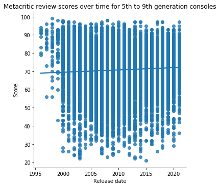

```python
old_games["release_year"] = old_games["release_date"].apply(lambda x: (int)(x.year))
new_games["release_year"] = new_games["release_date"].apply(lambda x: (int)(x.year))
games["release_year"] = games["release_date"].apply(lambda x: (int)(x.year))

sns.lmplot(x = "release_year", y = "meta_score", data = games, ci = None, fit_reg = True)
plt.xlabel("Release date")
plt.ylabel("Score")
plt.title("Metacritic review scores over time for 5th to 9th generation consoles")
plt.show()
```

As shown in the graph above, there seems to a small insignificant positive trend between the score and the release year.

Seeing the little growth, we wanted to see if there was a more significant trend between the 5th and 6th generation consoles and 7th to 9th generation consoles. The results are shown below.

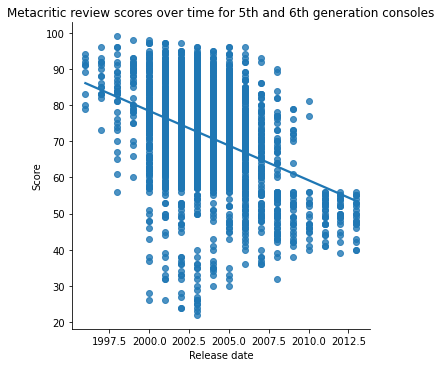

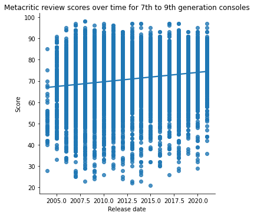

```python
sns.lmplot(x = "release_year", y = "meta_score", data = old_games, ci = None, fit_reg = True)
plt.xlabel("Release date")
plt.ylabel("Score")
plt.title("Metacritic review scores over time for 5th and 6th generation consoles")
plt.show()

sns.lmplot(x = "release_year", y = "meta_score", data = new_games, ci = None, fit_reg = True)
plt.xlabel("Release date")
plt.ylabel("Score")
plt.title("Metacritic review scores over time for 7th to 9th generation consoles")
plt.show()
```

As shown in the two graphs above, the trend for the 5th and 6th generation consoles has a huge and significant downward trend, but for the 7th to 9th generation consoles, there seems to be a small positive trend. This would explain why when we graphed the Metacritic review scores over time for 5th to 9th generation consoles, there wasn't a strong trend: the two trends cancelled each other out overall.

```python
reg = sklearn.linear_model.LinearRegression().fit(games[["release_year"]], games["meta_score"])
print("Overall score increase per year is", reg.coef_[0])
reg = sklearn.linear_model.LinearRegression().fit(old_games[["release_year"]], old_games["meta_score"])
print("Score increase per year for games on old consoles is", reg.coef_[0])
reg = sklearn.linear_model.LinearRegression().fit(new_games[["release_year"]], new_games["meta_score"])
print("Score increase per year for games on new consoles is", reg.coef_[0])
```

```
Overall score increase per year is 0.12642109642337582
Score increase per year for games on old consoles is -1.9163610909011795
Score increase per year for games on new consoles is 0.4405766212115199
```

These coefficients tell us the exact rates of increase for the lines of best fit in the graphs above. Just as the graphs show, there is a slight increase in scores overall, but at only 0.12 points per year, it is tough to say how significant.

We wanted to investigate this further, so we graphed two violin plots. The first violin plot graphed the Metacritic review score over time, while the second violin plot graphed the Metacritic review score for each console.

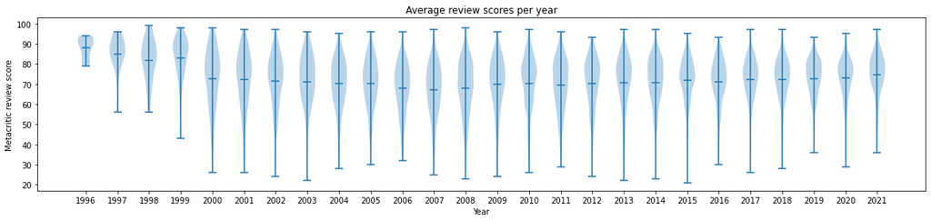

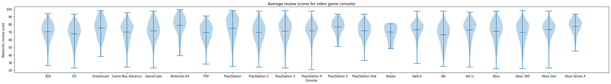

```python
list_by_year = []
for year in games.groupby("release_year").groups:
   year_metascore = games[games["release_year"] == year]["meta_score"].tolist()
   list_by_year.append(year_metascore)
fig, ax = plt.subplots()
ax.violinplot(list_by_year, showmeans = True)
ax.set_xlabel("Year")
ax.set_ylabel("Metacritic review score")
ax.set_title("Average review scores per year")
fig.set_figwidth(20)
plt.xticks(range(1, len(games.groupby("release_year").groups) + 1), games.groupby("release_year").groups)
plt.show()

list_by_consoles = []
for console in games.groupby("platform").groups:
   console_metascore = games[games["platform"] == console]["meta_score"].tolist()
   list_by_consoles.append(console_metascore)
fig, ax = plt.subplots()
ax.violinplot(list_by_consoles, showmeans = True)
ax.set_xlabel("Console")
ax.set_ylabel("Metacritic review score")
ax.set_title("Average review scores for video game consoles")
fig.set_figwidth(35)
plt.xticks(range(1, len(games["platform"].drop_duplicates()) + 1), games.groupby("platform").groups)
plt.show()
```

Based on the two violin plots shown above it seems that earlier video gaming consoles had an overall high metacritic review score with a low spread but over time the spread had increased while the mediam review score decreased up to the year 2000. From the year 2000 the average metacritic review score decreased slightly until the year 2007 but ever since then has been increasing slightly up to the year 2021. Furthermore, since the year 2000 the average spread seems to be oscillating slightly throughout the years.

Even with these violin plots, the exact difference between old and new consoles was unclear. We created one last violin plot, focusing on each category of console.

[figure not shown]

```python
list_by_category = []
for category in [0, 1]:
   category_metascore = games[games["new_console"] == category]["meta_score"].tolist()
   list_by_category.append(category_metascore)
fig, ax = plt.subplots()
ax.violinplot(list_by_category, showmeans = True)
ax.set_xlabel("Console generation")
ax.set_ylabel("Metacritic review score")
ax.set_title("Average review scores for 5th-6th and 7th-9th generation consoles")
plt.xticks(range(1, 3), ["5th-6th", "7th-9th"])
plt.show()
```

This violin plot makes the difference between each category, or rather the lack of difference, apparent. The pre- and post-7th generation console categories each have an average score at around 70.

## Linear regression

Now we can determine just how significant these trends are. To start, we create a linear regression model for review scores, based on two interaction terms: whether or not a game's console is pre- or post-7th generation, and a game's release year.

```python
X = games[["new_console", "release_year"]]
y = games["meta_score"]
reg = sklearn.linear_model.LinearRegression().fit(X, y)
print(reg.coef_)
```

```
[-1.83092777  0.21212776]
```

These coefficients tell us that a game being on a new console has a negative impact on the game's score, outweighing the positive impact of a game's release date being one year later.

Calculating the p-values of each interaction term will tell us how significant each interaction term is to the score.

```python
regressor_OLS = sm.OLS(endog = y, exog = X).fit()
print(regressor_OLS.summary())
print(regressor_OLS.pvalues)
```

```
                                 OLS Regression Results
=======================================================================================
Dep. Variable:             meta_score   R-squared (uncentered):                   0.970
Model:                            OLS   Adj. R-squared (uncentered):              0.970
Method:                 Least Squares   F-statistic:                          2.069e+05
Date:                Mon, 16 May 2022   Prob (F-statistic):                        0.00
Time:                        08:27:18   Log-Likelihood:                         -50338.
No. Observations:               12775   AIC:                                  1.007e+05
Df Residuals:                   12773   BIC:                                  1.007e+05
Df Model:                           2
Covariance Type:            nonrobust
================================================================================
                   coef    std err          t      P>|t|      [0.025      0.975]
--------------------------------------------------------------------------------
new_console     -0.1958      0.257     -0.761      0.447      -0.700       0.309
release_year     0.0353      0.000    317.229      0.000       0.035       0.036
==============================================================================
Omnibus:                     1120.341   Durbin-Watson:                   0.000
Prob(Omnibus):                  0.000   Jarque-Bera (JB):             1451.232
Skew:                          -0.771   Prob(JB):                         0.00
Kurtosis:                       3.588   Cond. No.                     4.70e+03
==============================================================================

Warnings:
[1] Standard Errors assume that the covariance matrix of the errors is correctly specified.
[2] The condition number is large, 4.7e+03. This might indicate that there are
strong multicollinearity or other numerical problems.
new_console     0.446859
release_year    0.000000
dtype: float64
```

The p-value for a game's console generation category is 0.447, suggesting that the null hypothesis is valid. In other words, the relationship is just like our violin plots visualized. There is no clear correlation between whether a game released on a pre- or post-7th generation console and its review score.

```python
%%shell
jupyter nbconvert --to html /content/Final_Project.ipynb
```

```
[NbConvertApp] Converting notebook /content/Final_Project.ipynb to html
[NbConvertApp] Writing 628841 bytes to /content/Final_Project.html
```